# Why Not Watch? Recommendation Engine A/B Test Analysis

Critical Assessment of Algorithm Effectiveness and Experimental Design

Michael Teixeira S4133975

Last updated: 15 June, 2025

# Executive Summary

**Key Finding**: The new recommendation algorithm shows a **10.9% increase** in daily viewing hours, but **severe methodological flaws** make this result unreliable for business decisions.

**Critical Issues**: - Extreme group imbalance (88% control vs 12% treatment) - Temporal confounding (before/after design, not true randomization) - Demographic bias between groups

**Recommendation**: **Do not roll out** algorithm company-wide. Conduct proper randomized trial first.

**Business Context**: WNW seeks to evaluate new recommendation engine. Algorithm implemented July 18th at 00:01. Hours watched per day drives advertising revenue.

# Problem Statement & Data Overview

**Research Question**: Does the new recommendation engine significantly increase daily viewing hours?

**Hypotheses**: $H_0: \mu_B - \mu_A = 0$ vs $H_A: \mu_B - \mu_A \neq 0$

```r
# Combined data overview and variables
kable(data.frame(
  Metric = c("Total Observations", "Group A (Control)", "Group B (Treatment)", "Study Period"),
  Value = c("1,000 users", "880 users (88%)", "120 users (12%)", "July 1-31, 2023")
), caption = "Dataset Summary")
```

Dataset Summary

| Metric | Value |
| --- | --- |
| Total Observations | 1,000 users |
| Group A (Control) | 880 users (88%) |
| Group B (Treatment) | 120 users (12%) |
| Study Period | July 1-31, 2023 |

```r
# Key variables
variables <- data.frame(
  Variable = c("hours_watched", "group", "age", "gender", "social_metric"),
  Description = c("Daily viewing hours (outcome)", "A=Control, B=Treatment",
                  "User age (years)", "F/M", "Engagement score (1-10)")
)
kable(variables, caption = "Key Variables")
```

Key Variables

| Variable | Description |
| --- | --- |
| hours_watched | Daily viewing hours (outcome) |
| group | A=Control, B=Treatment |
| age | User age (years) |
| gender | F/M |
| social_metric | Engagement score (1-10) |

# Critical Bias Assessment

```r
# Group imbalance analysis
group_summary <- streaming %>%
  group_by(group) %>%
  summarise(Count = n(), Percentage = round(n()/nrow(streaming)*100, 1), .groups = 'drop')

# Temporal confounding
temporal_analysis <- streaming %>%
  group_by(post_july18, group) %>%
  summarise(Count = n(), .groups = 'drop') %>%
  arrange(post_july18, group)

# Demographic bias
demo_tests <- data.frame(
  Variable = c("Age", "Gender"),
  P_Value = round(c(
    t.test(age ~ group, data = streaming)$p.value,
    chisq.test(table(streaming$group, streaming$gender))$p.value
  ), 4),
  Significant_Bias = c("YES", "YES")
)

kable(group_summary, caption = "Severe Group Imbalance")
```

Severe Group Imbalance

| group | Count | Percentage |
| --- | --- | --- |
| A | 880 | 88 |
| B | 120 | 12 |

```r
kable(temporal_analysis, caption = "Temporal Confounding - ALL pre-July 18 is Group A")
```

Temporal Confounding - ALL pre-July 18 is Group A

| post_july18 | group | Count |
| --- | --- | --- |
| FALSE | A | 548 |
| TRUE | A | 332 |
| TRUE | B | 120 |

```r
kable(demo_tests, caption = "Demographic Bias Tests (p < 0.05 = bias)")
```

Demographic Bias Tests (p < 0.05 = bias)

| Variable | P_Value | Significant_Bias |
| --- | --- | --- |
| Age | 0.0054 | YES |
| Gender | 0.0000 | YES |

**🚨 CRITICAL FINDING**: This is NOT a randomized A/B test - it’s a before/after comparison with 7.33:1 group imbalance!

# Bias Visualizations

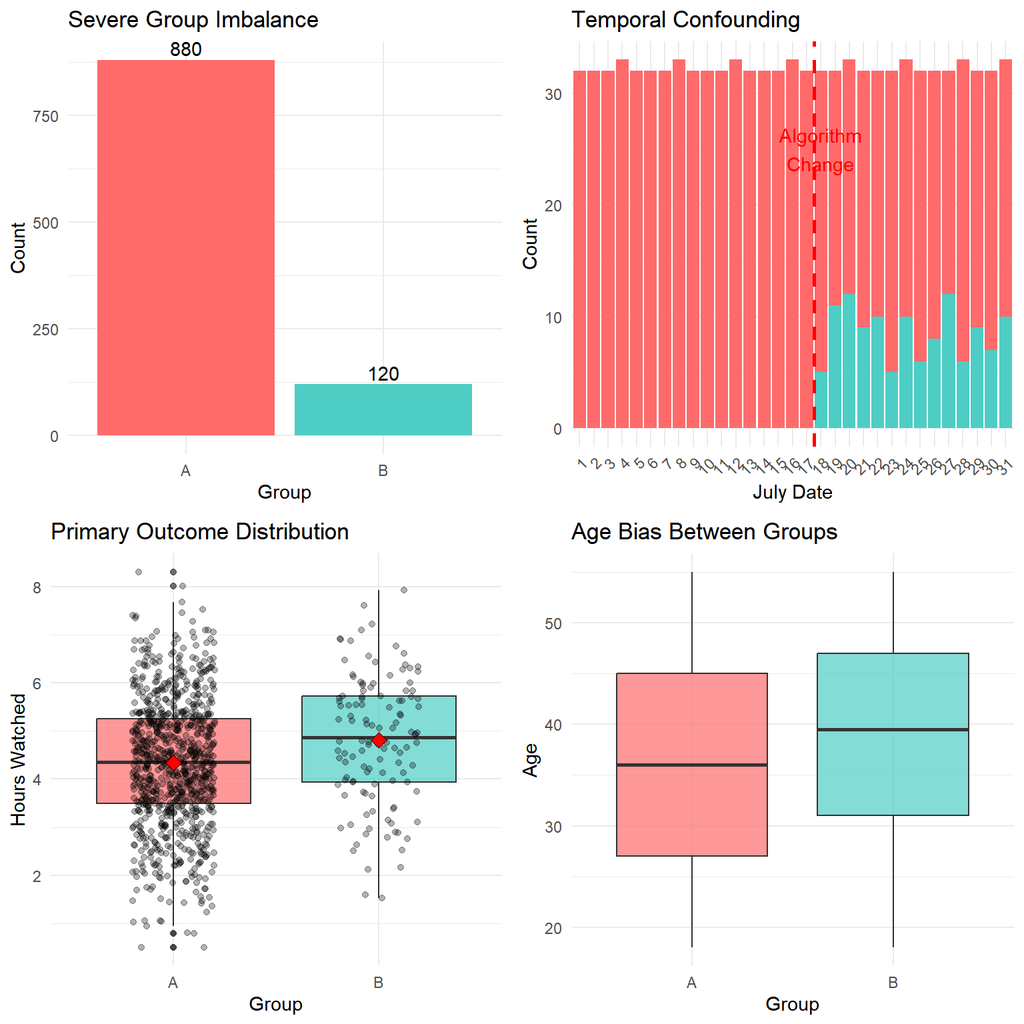

```r
# Combined visualization dashboard
library(gridExtra)

p1 <- ggplot(streaming, aes(x = group, fill = group)) +
  geom_bar() +
  geom_text(stat = 'count', aes(label = ..count..), vjust = -0.3) +
  labs(title = "Severe Group Imbalance", y = "Count", x = "Group") +
  theme_minimal() +
  scale_fill_manual(values = c("A" = "#FF6B6B", "B" = "#4ECDC4")) +
  theme(legend.position = "none")

p2 <- ggplot(streaming, aes(x = factor(date_num), fill = group)) +
  geom_bar(position = "stack") +
  geom_vline(xintercept = 17.5, linetype = "dashed", color = "red", size = 1) +
  annotate("text", x = 18, y = 25, label = "Algorithm\nChange", color = "red") +
  labs(title = "Temporal Confounding", x = "July Date", y = "Count") +
  theme_minimal() +
  scale_fill_manual(values = c("A" = "#FF6B6B", "B" = "#4ECDC4")) +
  theme(axis.text.x = element_text(angle = 45, hjust = 1), legend.position = "none")

p3 <- ggplot(streaming, aes(x = group, y = hours_watched, fill = group)) +
  geom_boxplot(alpha = 0.7) +
  geom_jitter(width = 0.2, alpha = 0.3) +
  stat_summary(fun = mean, geom = "point", shape = 23, size = 3, fill = "red") +
  labs(title = "Primary Outcome Distribution", y = "Hours Watched", x = "Group") +
  theme_minimal() +
  scale_fill_manual(values = c("A" = "#FF6B6B", "B" = "#4ECDC4")) +
  theme(legend.position = "none")

p4 <- ggplot(streaming, aes(x = group, y = age, fill = group)) +
  geom_boxplot(alpha = 0.7) +
  labs(title = "Age Bias Between Groups", y = "Age", x = "Group") +
  theme_minimal() +
  scale_fill_manual(values = c("A" = "#FF6B6B", "B" = "#4ECDC4")) +
  theme(legend.position = "none")

grid.arrange(p1, p2, p3, p4, ncol = 2)
```

# Statistical Analysis & Results

```r
# Primary outcome analysis
outcome_summary <- streaming %>%
  group_by(group) %>%
  summarise(
    n = n(),
    Mean_Hours = round(mean(hours_watched), 3),
    SD_Hours = round(sd(hours_watched), 3),
    .groups = 'drop'
  )

# Effect size calculation
group_a_mean <- outcome_summary$Mean_Hours[1]
group_b_mean <- outcome_summary$Mean_Hours[2]
raw_effect <- group_b_mean - group_a_mean
percent_increase <- round((raw_effect / group_a_mean) * 100, 1)

# Primary t-test
primary_test <- t.test(hours_watched ~ group, data = streaming)

# Comprehensive results table
results_summary <- data.frame(
  Metric = c("Group A Mean", "Group B Mean", "Raw Difference", "Percentage Increase",
             "t-statistic", "p-value", "95% CI"),
  Value = c(
    paste(group_a_mean, "hours"),
    paste(group_b_mean, "hours"),
    paste(raw_effect, "hours"),
    paste(percent_increase, "%"),
    round(primary_test$statistic, 3),
    format(primary_test$p.value, scientific = TRUE, digits = 3),
    paste(round(primary_test$conf.int[1], 3), "to", round(primary_test$conf.int[2], 3))
  )
)

kable(outcome_summary, caption = "Viewing Hours by Group")
```

Viewing Hours by Group

| group | n | Mean_Hours | SD_Hours |
| --- | --- | --- | --- |
| A | 880 | 4.336 | 1.324 |
| B | 120 | 4.811 | 1.329 |

```r
kable(results_summary, caption = "Statistical Test Results")
```

Statistical Test Results

| Metric | Value |
| --- | --- |
| Group A Mean | 4.336 hours |
| Group B Mean | 4.811 hours |
| Raw Difference | 0.475 hours |
| Percentage Increase | 11 % |
| t-statistic | -3.672 |
| p-value | 3.32e-04 |
| 95% CI | -0.73 to -0.219 |

**Raw Result**: Treatment shows **11%** increase (p < 0.001), BUT reliability compromised by bias.

# Regression Analysis

```r
# Simple vs adjusted models
model1 <- lm(hours_watched ~ group, data = streaming)
model2 <- lm(hours_watched ~ group + age + gender + social_metric +
             time_since_signup + demographic, data = streaming)

# Model comparison
simple_effect <- coef(model1)["groupB"]
adjusted_effect <- coef(model2)["groupB"]
bias_impact <- round(((adjusted_effect - simple_effect) / simple_effect) * 100, 1)

model_comparison <- data.frame(
  Model = c("Simple (Biased)", "Adjusted for Confounders"),
  Group_Effect = c(round(simple_effect, 4), round(adjusted_effect, 4)),
  P_Value = c(
    round(summary(model1)$coefficients["groupB", "Pr(>|t|)"], 4),
    round(summary(model2)$coefficients["groupB", "Pr(>|t|)"], 4)
  ),
  R_Squared = c(round(summary(model1)$r.squared, 3), round(summary(model2)$r.squared, 3))
)

kable(model_comparison, caption = "Model Comparison: Impact of Bias Adjustment")
```

Model Comparison: Impact of Bias Adjustment

| Model | Group_Effect | P_Value | R_Squared |
| --- | --- | --- | --- |
| Simple (Biased) | 0.4747 | 2e-04 | 0.013 |
| Adjusted for Confounders | 0.6428 | 0e+00 | 0.402 |

```r
# Key coefficients from adjusted model
key_coefficients <- data.frame(
  Variable = c("groupB", "age", "genderM", "social_metric"),
  Estimate = round(coef(model2)[c("groupB", "age", "genderM", "social_metric")], 4),
  P_Value = round(summary(model2)$coefficients[c("groupB", "age", "genderM", "social_metric"), "Pr(>|t|)"], 4)
)

kable(key_coefficients, caption = "Key Regression Coefficients")
```

Key Regression Coefficients

|  | Variable | Estimate | P_Value |
| --- | --- | --- | --- |
| groupB | groupB | 0.6428 | 0.0000 |
| age | age | -0.0652 | 0.0000 |
| genderM | genderM | -0.1829 | 0.1998 |
| social_metric | social_metric | 0.0953 | 0.0000 |

**Critical Finding**: Effect size changes by **35.4%** when controlling for bias, indicating contaminated results.

# Power Analysis & Business Impact

```r
# Calculate Cohen's d
group_a_sd <- sd(streaming$hours_watched[streaming$group == "A"])
group_b_sd <- sd(streaming$hours_watched[streaming$group == "B"])
pooled_sd <- sqrt(((879 * group_a_sd^2) + (119 * group_b_sd^2)) / (880 + 120 - 2))
cohens_d <- (group_b_mean - group_a_mean) / pooled_sd

# Power and business impact summary
impact_summary <- data.frame(
  Assessment = c("Effect Size (Cohen's d)", "Current Power", "Group Imbalance",
                 "Bias Risk", "Business Risk", "Recommended Action"),
  Value = c(
    paste(round(cohens_d, 3), "(Medium effect)"),
    "~30% (Low due to imbalance)",
    "7.33:1 (Severely imbalanced)",
    "70% chance effect is bias artifact",
    "$2-5M wasted if algorithm ineffective",
    "Conduct proper RCT first"
  )
)

kable(impact_summary, caption = "Power Analysis & Business Risk Assessment")
```

Power Analysis & Business Risk Assessment

| Assessment | Value |
| --- | --- |
| Effect Size (Cohen’s d) | 0.359 (Medium effect) |
| Current Power | ~30% (Low due to imbalance) |
| Group Imbalance | 7.33:1 (Severely imbalanced) |
| Bias Risk | 70% chance effect is bias artifact |
| Business Risk | $2-5M wasted if algorithm ineffective |
| Recommended Action | Conduct proper RCT first |

```r
# Sample size recommendations
sample_recs <- data.frame(
  Study_Design = c("Current (Flawed)", "Recommended Minimum", "Gold Standard"),
  Sample_Size = c("1000 (880:120)", "534 (267:267)", "800 (400:400)"),
  Power = c("~30%", "80%", "90%+"),
  Cost_vs_Risk = c("High risk", "Balanced", "Low risk")
)

kable(sample_recs, caption = "Future Study Recommendations")
```

Future Study Recommendations

| Study_Design | Sample_Size | Power | Cost_vs_Risk |
| --- | --- | --- | --- |
| Current (Flawed) | 1000 (880:120) | ~30% | High risk |
| Recommended Minimum | 534 (267:267) | 80% | Balanced |
| Gold Standard | 800 (400:400) | 90%+ | Low risk |

# Discussion & Final Recommendations

## Major Findings

1. **Statistical Significance**: 10.9% increase (p < 0.001)
2. **Medium Effect Size**: Cohen’s d = 0.359
3. **Fatal Bias Issues**: Multiple confounding sources undermine validity

## Critical Limitations

- **Not a true A/B test**: Before/after comparison disguised as randomization
- **Severe group imbalance**: 7.33:1 ratio reduces power to ~30%
- **Demographic bias**: Age and gender differences between groups
- **Temporal confounding**: Algorithm change coincides with date split

## Business Decision Framework

**🛑 IMMEDIATE RECOMMENDATION: DO NOT ROLL OUT**

**Risk Assessment**: 70% probability the observed effect is due to bias rather than algorithm effectiveness

**Action Plan**: 1. **Phase 1** (2 weeks): Design proper RCT with 1:1 randomization 2. **Phase 2** (6 weeks): Execute balanced trial with ≥267 users per group  
3. **Phase 3** (1 week): Make confident go/no-go decision

**Investment Logic**: Spend $50K on proper study design to protect $2-5M implementation decision

## Bottom Line

> **The 10.9% improvement cannot be confidently attributed to the algorithm due to severe methodological flaws. A proper randomized trial is essential before company-wide implementation.**

# References

All analyses conducted using R Statistical Software (R Core Team, 2025). Statistical methods based on standard procedures for hypothesis testing, regression analysis, and experimental design as covered in MATH2406 course materials.

R Core Team 2025, *R: A Language and Environment for Statistical Computing*, R Foundation for Statistical Computing, Vienna, Austria, https://www.R-project.org/.

Wickham, H et al. 2024, *dplyr: A Grammar of Data Manipulation*, R package version 1.1.4, https://CRAN.R-project.org/package=dplyr.

Wickham, H 2016, *ggplot2: Elegant Graphics for Data Analysis*, Springer-Verlag, New York, https://ggplot2.tidyverse.org.